# Assignment_2

Brandon Parmanand

04-1-2023

### Heart disease is one of the leading causing of death in the world. There are risk factors associated with developing heart disease or facotrs that when people are already with heart disease. In this project we will look at some factors associated with heart disease and see if we are able to predict heart disease The dataset was obtained from Data obtained from https://www.kaggle.com/datasets/fedesoriano/heart-failure-prediction which was released in 2021. Here are the variables we are working with with Heart Disease being the dependent variable.

#### Age: age of the patient [years]

#### Sex: sex of the patient [M: Male, F: Female]

#### ChestPainType: chest pain type [TA: Typical Angina, ATA: Atypical Angina, NAP: Non-Anginal Pain, ASY: Asymptomatic]

#### RestingBP: resting blood pressure [mm Hg]

#### Cholesterol: serum cholesterol [mm/dl]

#### FastingBS: fasting blood sugar [1: if FastingBS > 120 mg/dl, 0: otherwise]

#### RestingECG: resting electrocardiogram results [Normal: Normal, ST: having ST-T wave abnormality (T wave inversions and/or ST elevation or depression of > 0.05 mV), LVH: showing probable or definite left ventricular hypertrophy by Estes’ criteria]

#### MaxHR: maximum heart rate achieved [Numeric value between 60 and 202]

#### ExerciseAngina: exercise-induced angina [Y: Yes, N: No]

#### Oldpeak: oldpeak = ST [Numeric value measured in depression]

#### ST_Slope: the slope of the peak exercise ST segment [Up: upsloping, Flat: flat, Down: downsloping]

#### HeartDisease: output class [1: heart disease, 0: Normal]

### First I will read in the data and see if there is any cleaning needed.

```r
heart_data<-read.csv("heart.csv", stringsAsFactors = TRUE)
str(heart_data)
```

```
## 'data.frame':    918 obs. of  12 variables:
##  $ Age           : int  40 49 37 48 54 39 45 54 37 48 ...
##  $ Sex           : Factor w/ 2 levels "F","M": 2 1 2 1 2 2 1 2 2 1 ...
##  $ ChestPainType : Factor w/ 4 levels "ASY","ATA","NAP",..: 2 3 2 1 3 3 2 2 1 2 ...
##  $ RestingBP     : int  140 160 130 138 150 120 130 110 140 120 ...
##  $ Cholesterol   : int  289 180 283 214 195 339 237 208 207 284 ...
##  $ FastingBS     : int  0 0 0 0 0 0 0 0 0 0 ...
##  $ RestingECG    : Factor w/ 3 levels "LVH","Normal",..: 2 2 3 2 2 2 2 2 2 2 ...
##  $ MaxHR         : int  172 156 98 108 122 170 170 142 130 120 ...
##  $ ExerciseAngina: Factor w/ 2 levels "N","Y": 1 1 1 2 1 1 1 1 2 1 ...
##  $ Oldpeak       : num  0 1 0 1.5 0 0 0 0 1.5 0 ...
##  $ ST_Slope      : Factor w/ 3 levels "Down","Flat",..: 3 2 3 2 3 3 3 3 2 3 ...
##  $ HeartDisease  : int  0 1 0 1 0 0 0 0 1 0 ...
```

```r
summary(heart_data)
```

```
##       Age        Sex     ChestPainType   RestingBP      Cholesterol
##  Min.   :28.00   F:193   ASY:496       Min.   :  0.0   Min.   :  0.0
##  1st Qu.:47.00   M:725   ATA:173       1st Qu.:120.0   1st Qu.:173.2
##  Median :54.00           NAP:203       Median :130.0   Median :223.0
##  Mean   :53.51           TA : 46       Mean   :132.4   Mean   :198.8
##  3rd Qu.:60.00                         3rd Qu.:140.0   3rd Qu.:267.0
##  Max.   :77.00                         Max.   :200.0   Max.   :603.0
##    FastingBS       RestingECG      MaxHR       ExerciseAngina    Oldpeak
##  Min.   :0.0000   LVH   :188   Min.   : 60.0   N:547          Min.   :-2.6000
##  1st Qu.:0.0000   Normal:552   1st Qu.:120.0   Y:371          1st Qu.: 0.0000
##  Median :0.0000   ST    :178   Median :138.0                  Median : 0.6000
##  Mean   :0.2331                Mean   :136.8                  Mean   : 0.8874
##  3rd Qu.:0.0000                3rd Qu.:156.0                  3rd Qu.: 1.5000
##  Max.   :1.0000                Max.   :202.0                  Max.   : 6.2000
##  ST_Slope    HeartDisease
##  Down: 63   Min.   :0.0000
##  Flat:460   1st Qu.:0.0000
##  Up  :395   Median :1.0000
##             Mean   :0.5534
##             3rd Qu.:1.0000
##             Max.   :1.0000
```

```r
# Cholesterol nor resting heart rate cannot be 0, will need to remove those observations
heart_data$Cholesterol[heart_data$Cholesterol==0] <- NA
heart_data$RestingBP[heart_data$RestingBP==0] <- NA
# Need to change Fasting BC and Heart Disease to factors
heart_data$HeartDisease <- as.factor(heart_data$HeartDisease)
heart_data$FastingBS <- as.factor(heart_data$FastingBS)

sum(is.na(heart_data))
```

```
## [1] 173
```

```r
heart_data <- na.omit(heart_data)
sum(is.na(heart_data))
```

```
## [1] 0
```

```r
summary(heart_data)
```

```
##       Age        Sex     ChestPainType   RestingBP    Cholesterol    FastingBS
##  Min.   :28.00   F:182   ASY:370       Min.   : 92   Min.   : 85.0   0:621
##  1st Qu.:46.00   M:564   ATA:166       1st Qu.:120   1st Qu.:207.2   1:125
##  Median :54.00           NAP:169       Median :130   Median :237.0
##  Mean   :52.88           TA : 41       Mean   :133   Mean   :244.6
##  3rd Qu.:59.00                         3rd Qu.:140   3rd Qu.:275.0
##  Max.   :77.00                         Max.   :200   Max.   :603.0
##   RestingECG      MaxHR       ExerciseAngina    Oldpeak        ST_Slope
##  LVH   :176   Min.   : 69.0   N:459          Min.   :-0.1000   Down: 43
##  Normal:445   1st Qu.:122.0   Y:287          1st Qu.: 0.0000   Flat:354
##  ST    :125   Median :140.0                  Median : 0.5000   Up  :349
##               Mean   :140.2                  Mean   : 0.9016
##               3rd Qu.:160.0                  3rd Qu.: 1.5000
##               Max.   :202.0                  Max.   : 6.2000
##  HeartDisease
##  0:390
##  1:356
##
##
##
##
```

```r
t.test(heart_data$Age ~ heart_data$HeartDisease)
```

```
##
##  Welch Two Sample t-test
##
## data:  heart_data$Age by heart_data$HeartDisease
## t = -8.5555, df = 742.94, p-value < 2.2e-16
## alternative hypothesis: true difference in means between group 0 and group 1 is not equal to 0
## 95 percent confidence interval:
##  -6.982520 -4.376137
## sample estimates:
## mean in group 0 mean in group 1
##        50.17179        55.85112
```

```r
pval <- t.test(heart_data$Age ~ heart_data$HeartDisease)$p.value
pval
```

```
## [1] 6.681854e-17
```

```r
pval < 0.05
```

```
## [1] TRUE
```

```r
#The p-value is less than 0.05 on a 0.95 confidence interval. Reject the null hypotheses that there is strong statistical difference both outcomes.


set.seed(12345)
train.index <- sample(row.names(heart_data), 0.8*dim(heart_data)[1])
test.index <- setdiff(row.names(heart_data), train.index)
train.df <- heart_data[train.index, ]
test.df <- heart_data[test.index, ]
```

### Cholesterol and Resrting Heart Rate included values of 0 which is not possible for a living person. I turned these into NA and removed the NAs from the data. I also ran the data with strings as factors.Here I also broke the data out into training and testing dataset using 80% for training and the remaining 20% for testing/validation.

### Data Exploration

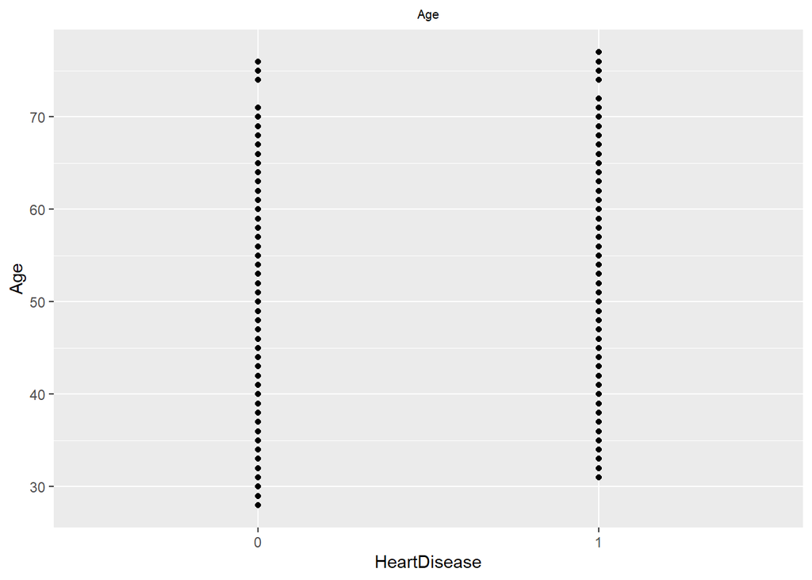

```r
Age_plot <- ggplot(heart_data, aes(HeartDisease, Age)) +
  geom_point() + ggtitle("Age") + theme(plot.title=element_text(size=8,hjust = 0.5))
Age_plot
```

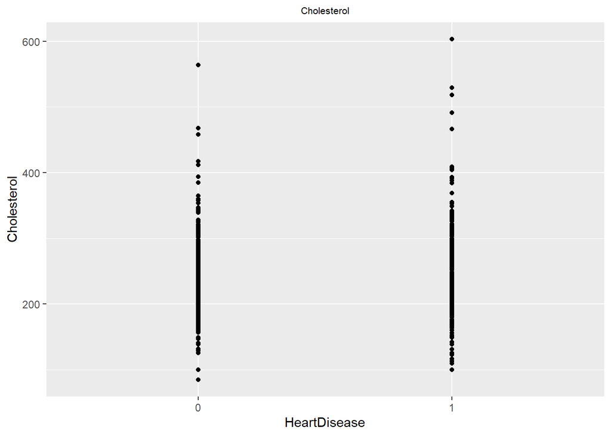

```r
Chol_plot <- ggplot(heart_data, aes(HeartDisease, Cholesterol)) +
  geom_point() + ggtitle("Cholesterol") + theme(plot.title=element_text(size=8,hjust = 0.5))
Chol_plot
```

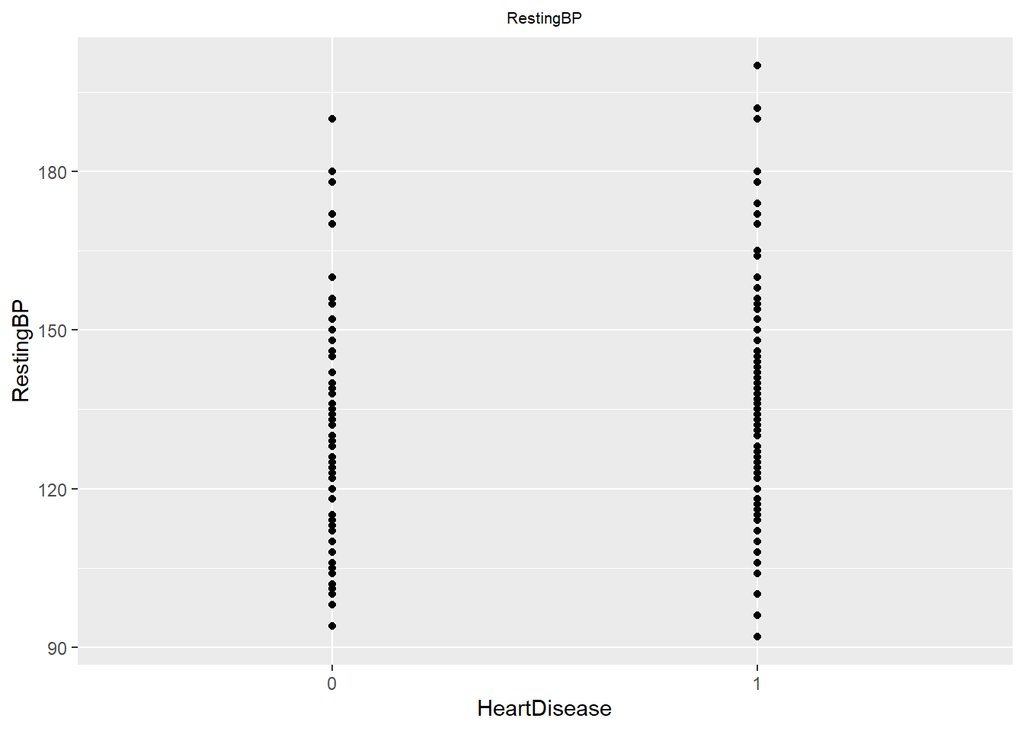

```r
BP_plot <- ggplot(heart_data, aes(HeartDisease, RestingBP)) +
  geom_point() + ggtitle("RestingBP") + theme(plot.title=element_text(size=8,hjust = 0.5))
BP_plot
```

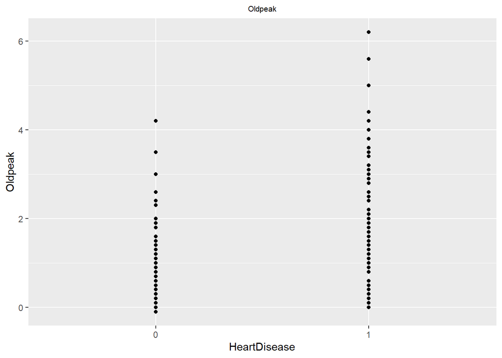

```r
ST_plot <- ggplot(heart_data, aes(HeartDisease, Oldpeak)) +
  geom_point() + ggtitle("Oldpeak") + theme(plot.title=element_text(size=8,hjust = 0.5))
ST_plot
```

### As expected, we see people with Heart disease are slightly older than people without heart disease. The same goes for cholesterol, resting BP and Oldpeak (which is ST depressions induced by exercise on the ECG) with more on the higher end of the scale.

## Statistical Models

### Logistic Regression

```r
log1 <- glm(HeartDisease ~ Age + Sex + ChestPainType + RestingBP + Cholesterol +
              FastingBS + RestingECG ++ MaxHR + ExerciseAngina + Oldpeak + ST_Slope,
            data = train.df, family = binomial(link = 'logit'))
summary(log1)
```

```
##
## Call:
## glm(formula = HeartDisease ~ Age + Sex + ChestPainType + RestingBP +
##     Cholesterol + FastingBS + RestingECG + +MaxHR + ExerciseAngina +
##     Oldpeak + ST_Slope, family = binomial(link = "logit"), data = train.df)
##
## Deviance Residuals:
##     Min       1Q   Median       3Q      Max
## -2.6372  -0.4019  -0.1092   0.4142   2.6413
##
## Coefficients:
##                   Estimate Std. Error z value Pr(>|z|)
## (Intercept)      -5.329615   1.989881  -2.678 0.007398 **
## Age               0.039409   0.016652   2.367 0.017953 *
## SexM              1.827134   0.345657   5.286 1.25e-07 ***
## ChestPainTypeATA -1.422442   0.392881  -3.621 0.000294 ***
## ChestPainTypeNAP -1.544813   0.339575  -4.549 5.38e-06 ***
## ChestPainTypeTA  -0.977224   0.529284  -1.846 0.064846 .
## RestingBP         0.016596   0.008661   1.916 0.055326 .
## Cholesterol       0.003727   0.002302   1.619 0.105365
## FastingBS1        0.489980   0.375242   1.306 0.191631
## RestingECGNormal -0.458843   0.315346  -1.455 0.145657
## RestingECGST     -0.744798   0.447863  -1.663 0.096312 .
## MaxHR            -0.004388   0.006389  -0.687 0.492232
## ExerciseAnginaY   1.002519   0.299396   3.348 0.000813 ***
## Oldpeak           0.288908   0.162310   1.780 0.075080 .
## ST_SlopeFlat      0.832896   0.582674   1.429 0.152879
## ST_SlopeUp       -1.834380   0.630167  -2.911 0.003603 **
## ---
## Signif. codes:  0 '***' 0.001 '**' 0.01 '*' 0.05 '.' 0.1 ' ' 1
##
## (Dispersion parameter for binomial family taken to be 1)
##
##     Null deviance: 824.06  on 595  degrees of freedom
## Residual deviance: 383.35  on 580  degrees of freedom
## AIC: 415.35
##
## Number of Fisher Scoring iterations: 6
```

```r
library(MASS)
result = stepAIC(log1, trace=1, direction="backward")
```

```
## Start:  AIC=415.35
## HeartDisease ~ Age + Sex + ChestPainType + RestingBP + Cholesterol +
##     FastingBS + RestingECG + +MaxHR + ExerciseAngina + Oldpeak +
##     ST_Slope
##
##                  Df Deviance    AIC
## - MaxHR           1   383.82 413.82
## - RestingECG      2   386.70 414.70
## - FastingBS       1   385.08 415.08
## <none>                383.35 415.35
## - Cholesterol     1   386.08 416.08
## - Oldpeak         1   386.59 416.59
## - RestingBP       1   387.06 417.06
## - Age             1   389.10 419.10
## - ExerciseAngina  1   394.44 424.44
## - ChestPainType   3   410.28 436.28
## - Sex             1   414.61 444.61
## - ST_Slope        2   464.29 492.29
##
## Step:  AIC=413.82
## HeartDisease ~ Age + Sex + ChestPainType + RestingBP + Cholesterol +
##     FastingBS + RestingECG + ExerciseAngina + Oldpeak + ST_Slope
##
##                  Df Deviance    AIC
## - RestingECG      2   386.80 412.80
## - FastingBS       1   385.53 413.53
## <none>                383.82 413.82
## - Cholesterol     1   386.51 414.51
## - Oldpeak         1   387.01 415.01
## - RestingBP       1   387.58 415.58
## - Age             1   391.36 419.36
## - ExerciseAngina  1   395.91 423.91
## - ChestPainType   3   412.89 436.89
## - Sex             1   415.37 443.37
## - ST_Slope        2   471.57 497.57
##
## Step:  AIC=412.8
## HeartDisease ~ Age + Sex + ChestPainType + RestingBP + Cholesterol +
##     FastingBS + ExerciseAngina + Oldpeak + ST_Slope
##
```

[output cut: 11 more lines]

```
##
## Step:  AIC=412.31
## HeartDisease ~ Age + Sex + ChestPainType + RestingBP + Cholesterol +
##     ExerciseAngina + Oldpeak + ST_Slope
##
##                  Df Deviance    AIC
## <none>                388.31 412.31
## - Oldpeak         1   391.73 413.73
## - Cholesterol     1   391.91 413.91
## - RestingBP       1   392.18 414.18
## - Age             1   398.58 420.58
## - ExerciseAngina  1   399.59 421.59
## - ChestPainType   3   416.43 434.43
## - Sex             1   421.74 443.74
## - ST_Slope        2   475.85 495.85
```

```r
print(result)
```

```
##
## Call:  glm(formula = HeartDisease ~ Age + Sex + ChestPainType + RestingBP +
##     Cholesterol + ExerciseAngina + Oldpeak + ST_Slope, family = binomial(link = "logit"),
##     data = train.df)
##
## Coefficients:
##      (Intercept)               Age              SexM  ChestPainTypeATA
##         -6.78205           0.04807           1.86272          -1.46290
## ChestPainTypeNAP   ChestPainTypeTA         RestingBP       Cholesterol
##         -1.52856          -0.96766           0.01658           0.00424
##  ExerciseAnginaY           Oldpeak      ST_SlopeFlat        ST_SlopeUp
##          0.99271           0.29505           0.75270          -1.91670
##
## Degrees of Freedom: 595 Total (i.e. Null);  584 Residual
## Null Deviance:       824.1
## Residual Deviance: 388.3     AIC: 412.3
```

```r
result$anova
```

```
## Stepwise Model Path
## Analysis of Deviance Table
##
## Initial Model:
## HeartDisease ~ Age + Sex + ChestPainType + RestingBP + Cholesterol +
##     FastingBS + RestingECG + +MaxHR + ExerciseAngina + Oldpeak +
##     ST_Slope
##
## Final Model:
## HeartDisease ~ Age + Sex + ChestPainType + RestingBP + Cholesterol +
##     ExerciseAngina + Oldpeak + ST_Slope
##
##
##           Step Df  Deviance Resid. Df Resid. Dev      AIC
## 1                                 580   383.3491 415.3491
## 2      - MaxHR  1 0.4697605       581   383.8188 413.8188
## 3 - RestingECG  2 2.9785349       583   386.7974 412.7974
## 4  - FastingBS  1 1.5105978       584   388.3080 412.3080
```

```r
# AIC is reduced from 415 to 412. Marginal difference and simplified model is better, removed Max HR, Resting ECG and Fasting BS

logistic <- glm(HeartDisease ~ Age + Sex + ChestPainType + RestingBP + Cholesterol +
    ExerciseAngina + Oldpeak + ST_Slope,
    data = train.df, family = binomial(link = 'logit'))


pdata <- predict(logistic, newdata = test.df, type = "response")
pdata <- ifelse(pdata>0.5, 1, 0)
pdata <- as.factor(pdata)

confusionMatrix(pdata, test.df$HeartDisease)
```

```
## Confusion Matrix and Statistics
##
##           Reference
## Prediction  0  1
##          0 60  5
##          1 14 71
##
##                Accuracy : 0.8733
##                  95% CI : (0.8093, 0.922)
##     No Information Rate : 0.5067
##     P-Value [Acc > NIR] : < 2e-16
##
##                   Kappa : 0.7462
##
##  Mcnemar's Test P-Value : 0.06646
##
##             Sensitivity : 0.8108
##             Specificity : 0.9342
##          Pos Pred Value : 0.9231
##          Neg Pred Value : 0.8353
##              Prevalence : 0.4933
##          Detection Rate : 0.4000
##    Detection Prevalence : 0.4333
##       Balanced Accuracy : 0.8725
##
##        'Positive' Class : 0
##
```

```r
#test.df$LogPred <- pdata
```

#### I first ran the logistic model with all variables with an AIC score of 415. I used the setpAIC Backward model to estimate a reduced model which removed the Max Heart rate, Resting ECG, and Fasting Blood sugar variables. THe AIC difference was marginal with an AIC of 412 for the simplified model. In this case I chose to move ahead with the simplified model to predict heart disease.

### Decision tree

```r
library(rpart)
```

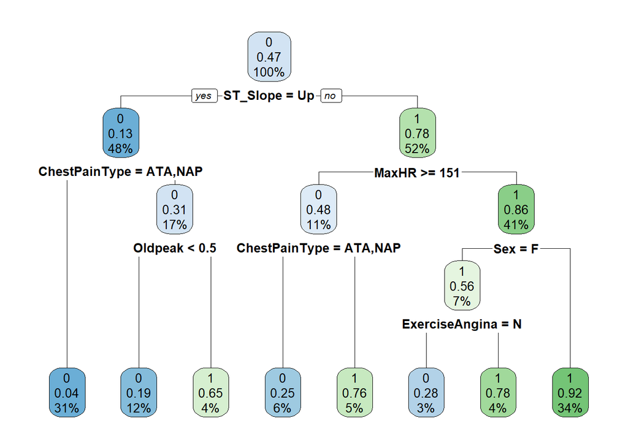

```r
library(rpart.plot)
set.seed(12345)


dec_tree <- rpart(HeartDisease ~., data = train.df)
#rpart.plot(dec_tree)
rpart.plot(dec_tree)
```

```r
summary(dec_tree)
```

```
## Call:
## rpart(formula = HeartDisease ~ ., data = train.df)
##   n= 596
##
##           CP nsplit rel error    xerror       xstd
## 1 0.62142857      0 1.0000000 1.0000000 0.04351524
## 2 0.03214286      1 0.3785714 0.3785714 0.03334032
## 3 0.01428571      3 0.3142857 0.3428571 0.03205084
## 4 0.01000000      7 0.2571429 0.3428571 0.03205084
##
## Variable importance
##       ST_Slope        Oldpeak ExerciseAngina  ChestPainType          MaxHR
##             28             19             15             14             13
##            Age            Sex    Cholesterol      RestingBP
##              7              2              1              1
##
## Node number 1: 596 observations,    complexity param=0.6214286
##   predicted class=0  expected loss=0.4697987  P(node) =1
##     class counts:   316   280
##    probabilities: 0.530 0.470
##   left son=2 (286 obs) right son=3 (310 obs)
##   Primary splits:
##       ST_Slope       splits as  RRL,       improve=124.84290, (0 missing)
##       ExerciseAngina splits as  LR,        improve= 89.78727, (0 missing)
##       Oldpeak        < 0.75  to the left,  improve= 79.58652, (0 missing)
##       ChestPainType  splits as  RLLL,      improve= 75.16942, (0 missing)
##       MaxHR          < 150.5 to the right, improve= 35.32361, (0 missing)
##   Surrogate splits:
##       Oldpeak        < 0.35  to the left,  agree=0.809, adj=0.601, (0 split)
##       ExerciseAngina splits as  LR,        agree=0.733, adj=0.444, (0 split)
##       ChestPainType  splits as  RLLR,      agree=0.686, adj=0.346, (0 split)
##       MaxHR          < 154.5 to the right, agree=0.671, adj=0.315, (0 split)
##       Age            < 54.5  to the left,  agree=0.621, adj=0.210, (0 split)
##
## Node number 2: 286 observations,    complexity param=0.01428571
##   predicted class=0  expected loss=0.1328671  P(node) =0.4798658
##     class counts:   248    38
##    probabilities: 0.867 0.133
##   left son=4 (187 obs) right son=5 (99 obs)
##   Primary splits:
```

[output cut: 117 more lines]

```
##
## Node number 15: 204 observations
##   predicted class=1  expected loss=0.07843137  P(node) =0.3422819
##     class counts:    16   188
##    probabilities: 0.078 0.922
##
## Node number 28: 18 observations
##   predicted class=0  expected loss=0.2777778  P(node) =0.03020134
##     class counts:    13     5
##    probabilities: 0.722 0.278
##
## Node number 29: 23 observations
##   predicted class=1  expected loss=0.2173913  P(node) =0.0385906
##     class counts:     5    18
##    probabilities: 0.217 0.783
```

```r
library(ggplot2)


tree_pred = predict(dec_tree,
                          newdata = test.df,
                          type = "prob")[, 2]
tree_pred <- ifelse(tree_pred>0.5, 1, 0)
tree_pred <- as.factor(tree_pred)
confusionMatrix(tree_pred, test.df$HeartDisease)
```

```
## Confusion Matrix and Statistics
##
##           Reference
## Prediction  0  1
##          0 53  8
##          1 21 68
##
##                Accuracy : 0.8067
##                  95% CI : (0.7343, 0.8665)
##     No Information Rate : 0.5067
##     P-Value [Acc > NIR] : 2.479e-14
##
##                   Kappa : 0.6124
##
##  Mcnemar's Test P-Value : 0.02586
##
##             Sensitivity : 0.7162
##             Specificity : 0.8947
##          Pos Pred Value : 0.8689
##          Neg Pred Value : 0.7640
##              Prevalence : 0.4933
##          Detection Rate : 0.3533
##    Detection Prevalence : 0.4067
##       Balanced Accuracy : 0.8055
##
##        'Positive' Class : 0
##
```

### XGboost

```r
data = heart_data

unique( data$HeartDisease )
```

```
## [1] 0 1
## Levels: 0 1
```

```r
ratioNoHeartDisease = sum( data$HeartDisease == 0 ) / sum( data$HeartDisease == 1 )
ratioNoHeartDisease
```

```
## [1] 1.095506
```

```r
library('Matrix')
data_mat = sparse.model.matrix(HeartDisease ~ . -HeartDisease, data=data )#notice the minus HeartDisease which is the dependent

library(caret)

set.seed(12345)

training_Inds = createDataPartition( data$HeartDisease , p=0.8 , list=FALSE , times=1 )
testing_Inds = seq( 1 , length(data$HeartDisease) )[ -training_Inds ]
training_Inds = as.vector(training_Inds)
testing_Inds = as.vector(testing_Inds)
print( paste('training inds len=',length(training_Inds),
             'testing inds len=',length(testing_Inds)) )
```

```
## [1] "training inds len= 597 testing inds len= 149"
```

```r
dim(data_mat)
```

```
## [1] 746  16
```

```r
y = as.matrix( data[,c("HeartDisease")] )
x = data_mat

xtrain = x[ training_Inds , ]
ytrain = y[ training_Inds ]
xtest = x[ testing_Inds , ]
ytest = y[ testing_Inds ]



library(xgboost)

param = list(objective = "binary:logistic",
             eval_metric = "error", # "error", error is the ratio of (wrong classes/all classes)
             scale_pos_weight = ratioNoHeartDisease,
             max_depth = 6,
             eta = 0.025,
             colsample_bytree = 0.5,
             min_child_weight = 1)



nrounds = 30
xgb = xgboost(params = param,
              data = xtrain,
              label = ytrain,
              nrounds = nrounds,
              verbose = 1,
              verbosity = 1)
PredictionsHeartDisease = predict( xgb , xtest )

PredictionsHeartDisease = ifelse( PredictionsHeartDisease > 0.5 , 1 , 0 )



confusionMatrix(table(PredictionsHeartDisease, ytest))
```

```
## Confusion Matrix and Statistics
##
##                        ytest
## PredictionsHeartDisease  0  1
##                       0 64 11
##                       1 14 60
##
##                Accuracy : 0.8322
##                  95% CI : (0.7624, 0.8884)
##     No Information Rate : 0.5235
##     P-Value [Acc > NIR] : 2.6e-15
##
##                   Kappa : 0.6643
##
##  Mcnemar's Test P-Value : 0.6892
##
##             Sensitivity : 0.8205
##             Specificity : 0.8451
##          Pos Pred Value : 0.8533
##          Neg Pred Value : 0.8108
##              Prevalence : 0.5235
##          Detection Rate : 0.4295
##    Detection Prevalence : 0.5034
##       Balanced Accuracy : 0.8328
##
##        'Positive' Class : 0
##
```

### The logistic regression had an Accuracy of .8733.

### The decision tree had and aAccuracy of .8067

### The XGboost model had an Accuracy of .8322

### In order to predict heart disease in patients, the logistic model has the highest accuracy.

```r
LogPred <-test.df
LogPred$LogPred <- pdata
head(LogPred)
```

```
##    Age Sex ChestPainType RestingBP Cholesterol FastingBS RestingECG MaxHR
## 9   37   M           ASY       140         207         0     Normal   130
## 11  37   F           NAP       130         211         0     Normal   142
## 19  60   M           ASY       100         248         0     Normal   125
## 20  36   M           ATA       120         267         0     Normal   160
## 22  44   M           ATA       120         184         0     Normal   142
## 29  53   F           ATA       113         468         0     Normal   127
##    ExerciseAngina Oldpeak ST_Slope HeartDisease LogPred
## 9               Y     1.5     Flat            1       1
## 11              N     0.0       Up            0       0
## 19              N     1.0     Flat            1       1
## 20              N     3.0     Flat            1       1
## 22              N     1.0     Flat            0       0
## 29              N     0.0       Up            0       0
```

```r
Dec_Pred <- test.df
Dec_Pred$Dec_Pred <- tree_pred
head(Dec_Pred)
```

```
##    Age Sex ChestPainType RestingBP Cholesterol FastingBS RestingECG MaxHR
## 9   37   M           ASY       140         207         0     Normal   130
## 11  37   F           NAP       130         211         0     Normal   142
## 19  60   M           ASY       100         248         0     Normal   125
## 20  36   M           ATA       120         267         0     Normal   160
## 22  44   M           ATA       120         184         0     Normal   142
## 29  53   F           ATA       113         468         0     Normal   127
##    ExerciseAngina Oldpeak ST_Slope HeartDisease Dec_Pred
## 9               Y     1.5     Flat            1        1
## 11              N     0.0       Up            0        0
## 19              N     1.0     Flat            1        1
## 20              N     3.0     Flat            1        0
## 22              N     1.0     Flat            0        1
## 29              N     0.0       Up            0        0
```